# Map Unit Spatial Summary Report

This report summarizes the geographic setting of a list of MUKEY within a file geodatabase. It is intented to be used to compare and contrast map units, and suggest possible Low, RV, and High values for components.

### Project Name

```
## [1] "SDJR - MLRA 111A - Crosby-Miami silt loams, 0 to 6 percent slopes"
```

### Variables

| Abbreviation | Measure | Units | Source |
| --- | --- | --- | --- |
| elev | elevation | meters | 30-meter USGS National Elevation Dataset (NED) |
| slope | slope gradient | percent | 10-meter NED |
| aspect | slope aspect | degrees | 10-meter NED |
| valley | multiresolution valley bottom index | unitless | 30-meter NED |
| wetness | topographic wetness index | unitless | 30-meter NED |
| relief | height above channel | meters | 30-meter NED |
| ppt | annual precipitation | millimeters | 800-meter 30-year normals (1981-2010) from PRISM Climate Dataset |
| temp | anuual air temperature | degrees Celsius | 800-meter 30-year normals (1981-2010) from PRISM Climate Dataset |
| ffp | frost free period | days | 1000-meter 30-year normals (1961-1990) from USFS RMRS |
| lulc | land use and land cover | landcover class (e.g. Woody Wetlands) | 2011 National Land Cover Dataset (NLCD) |

## Map of soil map units

Don’t be concerned if the soil map units don’t line up with the counties. The county layer being used is an internal R layer that is highly generalized.

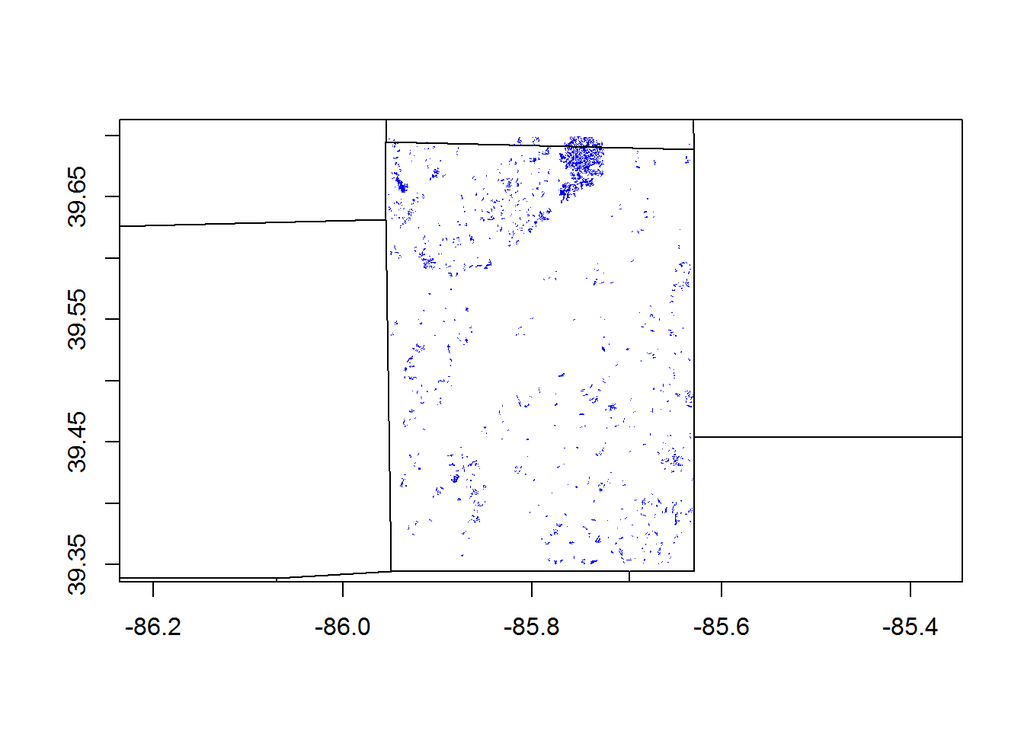

## Soil polygon metrics

Five number summary (min, 25th, median, 75th, max)(percentiles) and contingency table (counts)(n)

Summary of MUSYM by AREASYMBOL

|  | AREASYMBOL | MUSYM | variable | range | nPolygons | nArces |
| --- | --- | --- | --- | --- | --- | --- |
| 1 | IN145 | CsB | Acres | (0, 2, 3, 6, 1402) | 803 | 6092 |

## Polygon Boxplots

Graphical five number summary plus outliers (outliers, 5th, 25th, median, 75th, 95th, outliers)(percentiles). Circularity is a meature of shape complexity (Hole and Campbell, 1975), computed as mupolygon length / mupolygon circumference, with 1 being equal to a percent circle.

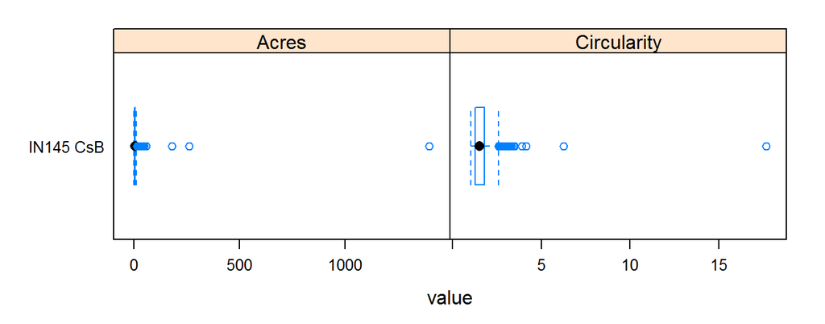

## Contingency tables (percent)

Slope breaks

|  | 0-2 | 2-6 | 6-12 | 12-18 | 18-30 | 30-50 | 50-75 | 75-350 |
| --- | --- | --- | --- | --- | --- | --- | --- | --- |
| IN145 CsB | 60 | 38 | 2 | 0 | 0 | 0 | 0 | 0 |
| new_mlra_mapunit | 60 | 38 | 2 | 0 | 0 | 0 | 0 | 0 |

Aspect breaks

|  | N | NE | E | SE | S | SW | W | NW |
| --- | --- | --- | --- | --- | --- | --- | --- | --- |
| IN145 CsB | 8 | 8 | 10 | 12 | 14 | 15 | 20 | 13 |
| new_mlra_mapunit | 8 | 8 | 10 | 12 | 14 | 15 | 20 | 13 |

Upland vs. lowland

|  | upland | lowland |
| --- | --- | --- |
| IN145 CsB | 2 | 98 |
| new_mlra_mapunit | 2 | 98 |

Landuse and Landcover

|  | Unclassified | NA | Open Water | Perennial Snow/Ice | Developed, Open Space | Developed, Low Intensity | Developed, Medium Intensity | Developed, High Intensity | Barren Land | Deciduous Forest | Evergreen Forest | Mixed Forest | Shrub/Scrub | Herbaceuous | Hay/Pasture | Cultivated Crops | Woody Wetlands | Emergent Herbaceuous Wetlands |
| --- | --- | --- | --- | --- | --- | --- | --- | --- | --- | --- | --- | --- | --- | --- | --- | --- | --- | --- |
| IN145 CsB | 0 | 0 | 0 | 0 | 5 | 1 | 0 | 0 | 0 | 4 | 0 | 0 | 0 | 1 | 3 | 85 | 0 | 0 |
| new_mlra_mapunit | 0 | 0 | 0 | 0 | 5 | 1 | 0 | 0 | 0 | 4 | 0 | 0 | 0 | 1 | 3 | 85 | 0 | 0 |

## Quantile breaks

Five number summary (min, 25th, median, 75th, max)(percentiles) and number of random samples (n)

|  | SSA_MUSYM | elev | slope | valley | wetness | relief | ppt | temp | ffp | n |
| --- | --- | --- | --- | --- | --- | --- | --- | --- | --- | --- |
| 1 | IN145 CsB | (210, 238, 251, 259, 281) | (0, 1, 1, 2, 27) | (0, 5, 6, 7, 8) | (10, 12, 13, 14, 21) | (0, 0, 1, 2, 16) | (1067, 1090, 1095, 1110, 1116) | (11, 11, 11, 11, 12) | (171, 173, 173, 174, 175) | 4149 |
| 2 | new_mlra_mapunit | (210, 238, 251, 259, 281) | (0, 1, 1, 2, 27) | (0, 5, 6, 7, 8) | (10, 12, 13, 14, 21) | (0, 0, 1, 2, 16) | (1067, 1090, 1095, 1110, 1116) | (11, 11, 11, 11, 12) | (171, 173, 173, 174, 175) | 4149 |

|  | SSA_MUSYM | aspect | n |
| --- | --- | --- | --- |
| 1 | IN145 CsB | (63, 302, 244, 163, 64) | 4149 |
| 2 | new_mlra_mapunit | (63, 302, 244, 163, 64) | 4149 |

## Boxplots of map unit properties

Graphical five number summary plus outliers (outliers, 5th, 25th, median, 75th, 95th, outliers)(percentiles)

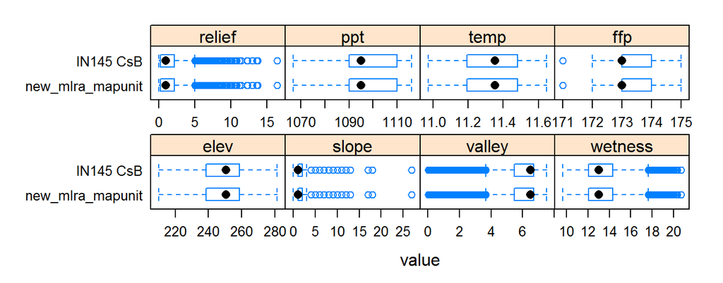